# The Superinvestors on the Corner of Berkshire-and-Fairfax

It’s been 35 years since Warren Buffett published The Superinvestors of Graham-and-Doddsville, his masterpiece arguing against the efficient market hypothesis by highlighting the track records of now famous value investing asset managers such as Charlie Munger, Walter Schloss, and Tweedy, Browne. By investing with any of the investors highlighted in Buffett’s article, one could have thoroughly thrashed the S&P 500 over a period of decades, even after accounting for the fees you’d have to pay for the privilege of having your money with them. 35 years is a long time, and the world has changed a lot in the decades since Buffett’s article was originally published. Investing no longer requires cutting a fat commission check to a full-service broker, stocks are now quoted to the penny rather than in fractions, and the internet has made company information is more widely and readily available than it has been in the history of the financial markets. The internet has brought us many invaluable websites, such as Facebook, Google, and YouTube. However, one of my favorites is one of the largest online value investing forums, called ‘Corner of Berkshire and Fairfax’ - named in reverence of Warren Buffett’s and Prem Watsa’s companies, Berkshire Hathaway and Fairfax Financial, which have created generational wealth for many longtime shareholders and serve as inspiration to investors around the world. The forum provides investors a platform to exchange and discuss stock ideas. With nearly 370,000 posts by over 3,300 members, it has served as an informal meeting place for investors from all walks of life and professional backgrounds, from hedge fund managers to fourth grade dropouts. As you can imagine, with such a diverse cast of characters and so many posts, the forum has been host to many incredible ideas that have performed extraordinarily well. Which made me wonder - what are the best ideas? Who are the members who have been submitting them? And has the rise of the internet created an opportunity to find the next generation of superinvestors to invest alongside, all without having to pay any fees? To find out, I scraped all the postings and checked Yahoo Finance for the respective tickers. Unfortunately, many companies have gone private or have been sold. As a result, the data for those companies is not as easily accessible and therefore not considered in this blog post. Furthermore, Yahoo Finance had some difficulties to find foreign companies. Nevertheless, the sample is big enough to do some exploratory data analysis!

##### Total Return

To start off, let’s look at the best performing users. Bmichaud is the clear leader, with an average return of 279.72%! However, as you can see, most of his returns actually came from one big idea - Netflix! The same is true for Viking, whose returns are mainly driven by Visa. Nevertheless, his ideas, on average, are up 169.48%! Visa was written up in early 2011 and achieved an annualized rate of return of 33% and got 257 replies on the message board. Interestingly, Mastercard, which was submited by Liberty in September 2011 compounded at a similar annualized rate, but got much less attention from the community with only 55 replies. The average return of all posts, is 46% and shown as the thin line in the chart.

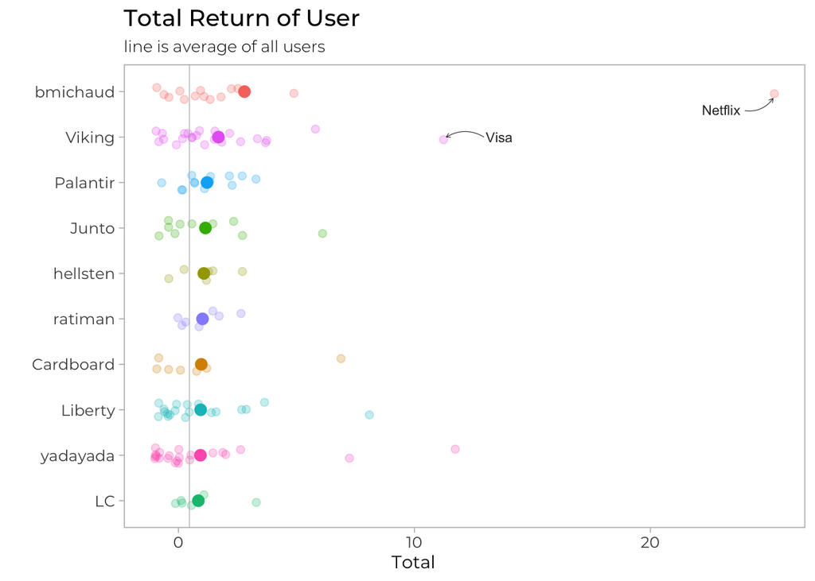

Let’s now zoom in a bit to ignore extreme outliers and get a better understanding of the average idea. Furthermore, to acknowledge the time trend that affects the stock market, I coloured the respective idea by the year it was posted. As can be expected, most best performing ideas were posted before 2016 and include large cap companies like Cisco, McDonald’s, Sony and Morgan Stanley. As was mentioned in the introduction, many companies were not found by yahoo finance. What’s even worse, is finding the wrong stock - such as CSU, which is ‘Capital Senior Living Corporation’, even though the original poster meant Constellation Software (CSU.TO), which would have performed tremendously.

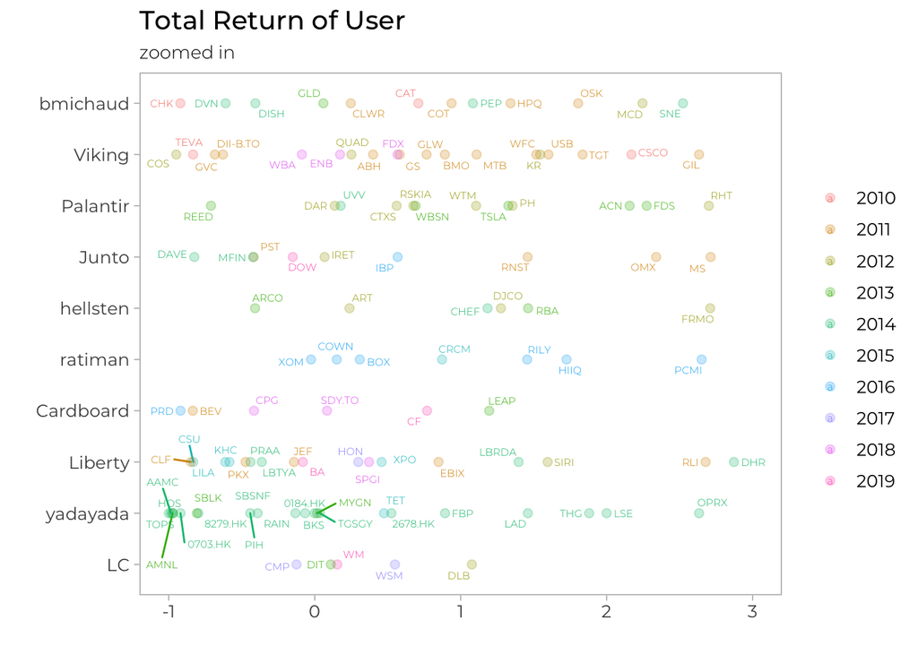

##### Compounded Growth

Of course, what really matters to investors is the compounded growth rate. If a stock has doubled, that might seem like a fantastic return… until you realize that it took 20 years to do it! So to get a better idea of performance, I annualized the performance of all users, which was only 1.4%! Since most ideas are long only anyway, there is little evidence that short ideas had a big effect on the annualized performance. Most people probably wouldn’t consider 1.4% to be a return worthy of the companies references in the forum’s name.. But even though the forum as a whole didn’t produce stunning returns, that doesn’t mean that there aren’t superinvestors lurking somewhere beneath the surface. So I decided to see how well the ideas of the very best members performed. So, I ranked every member by annualized return and have created a chart highlighting the results of the top ten. To make sure that the published ideas aren’t purely based on luck, I excluded users with less than 5 posts and required that the post was published more than 180 days ago.

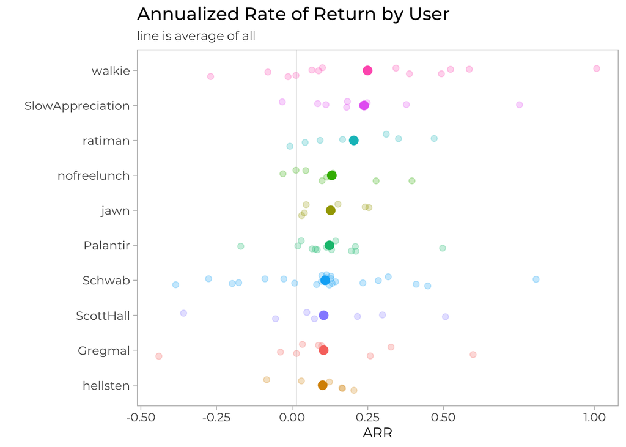

Just out of curiosity, let’s zoom in again!

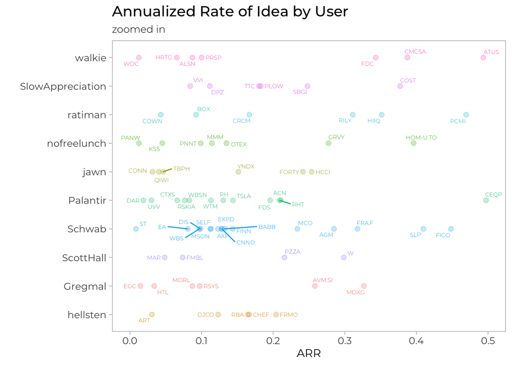

Let’s now take a look at the 10 best performing ideas. Interestingly, most are still relatively new and have performed tremendously since then.

```
##                user                                   name       arr year
## 1            walkie                                   AT&T 1.0065324 2018
## 2            Schwab                                 Dyadic 0.8062190 2017
## 3  SlowAppreciation                               ETSY.com 0.7514150 2017
## 4           Gregmal                               NVR Inc. 0.5981401 2018
## 5            walkie                        Blue Capital Re 0.5854961 2019
## 6            walkie                           Willis Lease 0.5235765 2017
## 7         ScottHall             California Orchard Company 0.5067107 2018
## 8          Palantir Crestwood Equity Midstream Partners LP 0.4972527 2016
## 9            walkie                             Altice USA 0.4934519 2018
## 10          ratiman                                   PCM  0.4694506 2016
```

Let’s look at another visualisation to better understand how time impacts the compounded annual growth rate. The visualisation clearly shows higher variance in the data for more recent ideas. It can therefore be argued, that newer ideas might both have better and worse performance. However, after applying statistical models, there was no significant evidence that blindly following those users will have an impact on annualized returns! Therefore, always do your own due diligence!

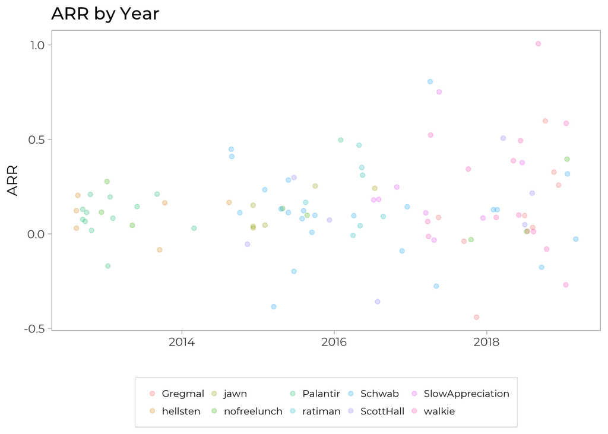

Lastly, I wanted to analyze whether replies have an effect on overall returns. A member of the forum put forward the hypothesis, that ideas with less comments generally perform better. This, can again can be tested with statistical models. The results are highly significant and indicate that ideas with a comment perform better by 0.001. However, each additional comment reduces performance by -0.00000013! Therefore, if you want to improve your performance you will do well by sticking to ideas with fewer comments.

##### Conclusion

This post showed that there truly are some superinvestors on the Corner of Berkshire and Fairfax! However, the average return of all posts on the forum in aggregate underperformed the market by a huge margin. Admittedly, there might be various factors - such as a general underperformance of the value factor or missing data. Nevertheless, I hope that we all gained some interesting insights with this short, but nevertheless time-consuming, analysis. You will find all the code and data here (link). Maybe you will find even better insights. If you do, feel free to share it with the community! Thanks go out to Liz for being awesome enough to edit this post for general readability and entertainment value!